# Meta-Analysis: Cox-PH Sensitivity Analysis

Meg Hutch

2022-12-06

This notebook evaluates the performance of Cox proportional hazard models constructed using three censor cutoff periods (30, 60, and 90 days) and three methods of adjusting for pre-admission health conditions (i.e., pre-existing comorbidity burden): (1) the inclusion of the 29 individual covariates (i.e., health conditions) comprising the Elixhauser Comorbidity Index, (2) the Elixhauser summary score, and (3) the top 10 principal components computed from logistic principal component analysis (LPCA).

We also perform additional meta-analyses in order to evaluate the estimates of the individual covariates (e.g., age, comoridities, etc) on each outcome.

Of note, this analysis is performed only on adult patients due to the pediatric cohort’s low incidence of both poor health outcomes and neurological diagnoses during COVID-19 hospitalization.

```r
library(tidyverse)
library(metafor)
library(meta)
library(cowplot)
library(DT)
library(ggbreak)
library(RColorBrewer)
library(viridis)
devtools::install_github("rdboyes/forester")
devtools::install_github("thomasp85/patchwork")
source("R/forester_custom.R")
source("R/analyze_survival.R")
```

# Import Data from each Healthcare system

```r
# read in files from results folder
# this folder contains all of the local healthcare system level analyses
rdas <- list.files(
  path = "results",
  pattern = ".rda",
  full.names = TRUE
)
for (rda in rdas) {
  load(rda)
}

rm(rdas, rda)

# create a list of participating healthcare systems from our study tracking spreadsheet
site_google_url <- "https://docs.google.com/spreadsheets/d/1epcYNd_0jCUMktOHf8mz5v651zy1JALD6PgzobrGWDY/edit?usp=sharing"

# load site parameters
site_params <- googlesheets4::read_sheet(site_google_url, sheet = 1)
site_avails <- googlesheets4::read_sheet(site_google_url, sheet = 2)

# filter the list of sites who ran the analysis
sorted_sites <- site_avails %>%
  filter(!is.na(date_v4_received)) %>%
  pull(siteid) %>%
  paste("results", sep = "_")

# list sites without race
sites_wo_race <- site_params %>%
  filter(!include_race) %>%
  pull(siteid)

# combine all rda files with 'results' in name
results <- mget(ls(pattern = "results"))

## read in pt counts
pt_counts_df <- read.csv('tables/site_pt_counts.csv')
```

## Identify sites to include in the analysis

We will only include a site if they have >= 3 neuro patients

```r
sites_adult <- pt_counts_df %>%
  filter(population == "Adult") %>%
  mutate(neuro_sum = n_var_Central + n_var_Peripheral) %>%
  filter(!neuro_sum < 3) %>%
  distinct(site) %>%
  mutate(site = gsub("_results", "", site))

sites_adult_results <- sites_adult %>% mutate(site = paste0(site, "_results")) %>% as.vector()

adult_results <- results[grepl(paste(sites_adult_results$site, collapse = "|"), names(results))]
```

## Define parameters

```r
outcomes <- c("time_first_discharge_reg_elix", "deceased_reg_elix")

comorb_adj <- c("lpca", "score", "ind")

censor_cut <- c("30", "60", "90")
```

## Get Cox model results - Adults

```r
cox_results_adults <- list()

for (outcome_i in outcomes) {
  for (comorb_adj_i in comorb_adj) {
    for (censor_cut_i in censor_cut) {

      cox_results_adults[[outcome_i]][[comorb_adj_i]][[censor_cut_i]] <-
        adult_results %>%
        lapply(get_cox_row, population = "adults", comorb_method = comorb_adj_i, censor_cutoff = censor_cut_i, outcome = outcome_i) %>%
        bind_rows() %>%
        mutate(outcome = outcome_i,
               comorb_method = comorb_adj_i,
               censor_cutoff = censor_cut_i)
    }
  }
}
```

## Evaluate concordance

```r
cox_concordance_results_adults <- list()

for (outcome_i in outcomes) {
  for (comorb_adj_i in comorb_adj) {
    for (censor_cut_i in censor_cut) {

      cox_concordance_results_adults[[outcome_i]][[comorb_adj_i]][[censor_cut_i]] <-
        adult_results %>%
        lapply(get_summary_stats, population = "adults", comorb_method = comorb_adj_i, censor_cutoff = censor_cut_i, outcome = outcome_i, cox_stat = "concordance") %>%
        bind_rows()
    }
  }
}
```

**Bind all concordance results together**

```r
bind_results <-  function(results_list) {

  lpca_discharge <- results_list[["time_first_discharge_reg_elix"]][["lpca"]] %>% bind_rows()

  score_discharge <- results_list[["time_first_discharge_reg_elix"]][["score"]] %>% bind_rows()

  ind_discharge <- results_list[["time_first_discharge_reg_elix"]][["ind"]] %>% bind_rows()

  lpca_mortality <- results_list[["deceased_reg_elix"]][["lpca"]] %>% bind_rows()

  score_mortality <- results_list[["deceased_reg_elix"]][["score"]] %>% bind_rows()

  ind_mortality <- results_list[["deceased_reg_elix"]][["ind"]] %>% bind_rows()

  combined_results <- bind_rows(lpca_discharge, score_discharge, ind_discharge,
                                   lpca_mortality, score_mortality, ind_mortality)

  return(combined_results)


}

cox_results <- bind_results(results_list = cox_results_adults)
concordance_results <- bind_results(results_list = cox_concordance_results_adults)
```

### **Concordance**

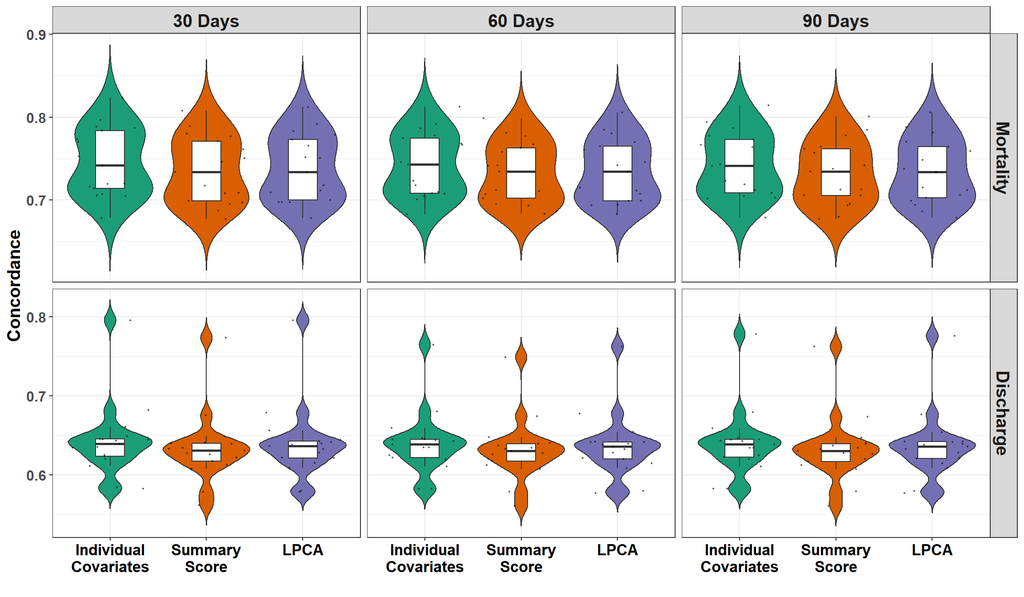

```r
c_plot <- ggplot(concordance_results %>%
         mutate(comorb_method = factor(comorb_method,
                                       levels = c("ind", "score", "lpca")) %>%
                  fct_recode(
                    `Individual\nCovariates` = "ind",
                    `Summary\nScore` = "score",
                    `LPCA` = "lpca"
                    ),
                outcome = as.factor(outcome) %>%
                  fct_recode(
                    Mortality = "deceased_reg_elix",
                    Discharge = "time_first_discharge_reg_elix"),
                censor_cutoff = as.factor(censor_cutoff) %>%
                  fct_recode(
                    `30 Days` = "30",
                    `60 Days` = "60",
                    `90 Days` = "90")),
       aes(x = comorb_method, y = C, group = comorb_method, fill = comorb_method)) +
  geom_violin(trim = FALSE) +
  facet_grid(outcome ~ censor_cutoff, scales = "free") +
  scale_y_continuous("Concordance", position="left") +
  xlab("") +
  theme_bw() +
  theme(legend.position = "none") +
  scale_fill_brewer(palette="Dark2") +
  geom_boxplot(width=0.3, fill="white", outlier.shape=NA) +
  geom_jitter(size = 0.4, alpha = 0.5, color = "black") +
  theme(strip.text.x = element_text(size = 15, face = "bold"),
        strip.text.y = element_text(size = 15, face = "bold"),
        axis.title.y = element_text(size = 15, face = "bold"),
        axis.text.x = element_text(size = 13, face = "bold", color = "black"),
        axis.text.y = element_text(size = 12, face = "bold"))

c_plot
```

```r
ggsave("figures/Comorbidity_adjustment.png", c_plot, width = 12, height = 7, dpi = 300)
```

```r
c_results <- concordance_results %>%
  group_by(outcome, censor_cutoff, comorb_method) %>%
  summarize(min = min(C),
            q1 = quantile(C, 0.25),
            median = median(C),
            mean = mean(C),
            q3 = quantile(C, 0.75),
            max = max(C)) %>%
    select(outcome, censor_cutoff, comorb_method, median, mean)
write.csv(c_results, "tables/comorbidity_adj_c_results.csv", row.names=FALSE)


# summary stats
datatable(concordance_results %>%
  group_by(outcome, censor_cutoff, comorb_method) %>%
  summarize(min = min(C),
            q1 = quantile(C, 0.25),
            median = median(C),
            mean = mean(C),
            q3 = quantile(C, 0.75),
            max = max(C)),
  filter="top")
```

|  | outcome | censor_cutoff | comorb_method | min | q1 | median | mean | q3 | max |
| --- | --- | --- | --- | --- | --- | --- | --- | --- | --- |
| 1 | deceased_reg_elix | 30 | ind | 0.6780197096817153 | 0.7137897375963855 | 0.7418603811390676 | 0.7460085981900537 | 0.7838424105148291 | 0.8234455449534999 |
| 2 | deceased_reg_elix | 30 | lpca | 0.6780197096817153 | 0.6999051841120965 | 0.7336572103761841 | 0.7380486967916902 | 0.7730132589931253 | 0.8120363000057096 |
| 3 | deceased_reg_elix | 30 | score | 0.6771873751498202 | 0.6988015061222416 | 0.733715684281127 | 0.7355942861047884 | 0.7709838426904102 | 0.8078648892829674 |
| 4 | deceased_reg_elix | 60 | ind | 0.6828482687219601 | 0.7082936270040925 | 0.742885788639061 | 0.7423845977386848 | 0.7746327037231655 | 0.8125972101872176 |
| 5 | deceased_reg_elix | 60 | lpca | 0.6828482687219601 | 0.6991985631284612 | 0.7342353934753463 | 0.7347580594020228 | 0.7650482025939833 | 0.8059206300176858 |
| 6 | deceased_reg_elix | 60 | score | 0.6835672380075923 | 0.701980580783604 | 0.7345890069401206 | 0.7324945184939683 | 0.7628391580544577 | 0.7988784438716238 |
| 7 | deceased_reg_elix | 90 | ind | 0.6783797107800176 | 0.7088462919454115 | 0.741287148699693 | 0.7417716119615615 | 0.7731641520022483 | 0.8142663445142829 |
| 8 | deceased_reg_elix | 90 | lpca | 0.6783797107800176 | 0.7027594258806455 | 0.7340027750662318 | 0.7343051739019164 | 0.764469430952883 | 0.8057880155820634 |
| 9 | deceased_reg_elix | 90 | score | 0.6769829097283084 | 0.7055107116332509 | 0.7345735082811103 | 0.7319440865328151 | 0.7616765202639371 | 0.8007212255095791 |
| 10 | time_first_discharge_reg_elix | 30 | ind | 0.5827178151321131 | 0.6234868407703504 | 0.6396152696325251 | 0.6425181935223102 | 0.6457484560740369 | 0.7954625087596356 |

[output cut: 8 more lines]

## Evaluate comorb_method with highest OR for CNS and PNS

```r
# summary stats
datatable(cox_results %>%
            filter(variable == "neuro_postCentral" | variable == "neuro_postPeripheral") %>%
            group_by(outcome, variable, censor_cutoff, comorb_method) %>%
            mutate(exp.coef. = round(exp.coef.)) %>%
            summarize(min = min(exp.coef., na.rm = TRUE),
                      q1 = quantile(exp.coef., 0.25, na.rm = TRUE),
                      median = median(exp.coef., na.rm = TRUE),
                      mean = mean(exp.coef. , na.rm = TRUE),
                      q3 = quantile(exp.coef., 0.75, na.rm = TRUE),
                      max = max(exp.coef., na.rm = TRUE)),
          filter="top")
```

```
## can override using the `.groups` argument.
```

|  | outcome | variable | censor_cutoff | comorb_method | min | q1 | median | mean | q3 | max |
| --- | --- | --- | --- | --- | --- | --- | --- | --- | --- | --- |
| 1 | deceased_reg_elix | neuro_postCentral | 30 | ind | 0 | 1 | 2 | 1.588235294117647 | 2 | 3 |
| 2 | deceased_reg_elix | neuro_postCentral | 30 | lpca | 0 | 1 | 2 | 1.588235294117647 | 2 | 3 |
| 3 | deceased_reg_elix | neuro_postCentral | 30 | score | 0 | 1 | 2 | 1.588235294117647 | 2 | 3 |
| 4 | deceased_reg_elix | neuro_postCentral | 60 | ind | 0 | 1 | 2 | 1.705882352941176 | 2 | 3 |
| 5 | deceased_reg_elix | neuro_postCentral | 60 | lpca | 1 | 1 | 2 | 1.8125 | 2 | 3 |
| 6 | deceased_reg_elix | neuro_postCentral | 60 | score | 0 | 1 | 2 | 1.647058823529412 | 2 | 3 |
| 7 | deceased_reg_elix | neuro_postCentral | 90 | ind | 0 | 1 | 2 | 1.647058823529412 | 2 | 3 |
| 8 | deceased_reg_elix | neuro_postCentral | 90 | lpca | 1 | 1 | 2 | 1.75 | 2 | 3 |
| 9 | deceased_reg_elix | neuro_postCentral | 90 | score | 0 | 1 | 2 | 1.588235294117647 | 2 | 3 |
| 10 | deceased_reg_elix | neuro_postPeripheral | 30 | ind | 0 | 0 | 0 | 0.3529411764705883 | 1 | 1 |

[output cut: 26 more lines]

## Random effects meta-analysis - CNS

set `sm = "HR"` when estimate is logHR (which is coef in our model): https://cran.r-project.org/web/packages/meta/meta.pdf - (search logHR in cran to see example)

```r
## adults
meta_results_adults_cns <- list()

for (outcome_i in outcomes) {
  for (comorb_adj_i in comorb_adj) {
    for (censor_cut_i in censor_cut) {

      meta_results_adults_cns[[outcome_i]][[comorb_adj_i]][[censor_cut_i]] <-
        cox_results %>%
        filter(outcome == outcome_i,
               comorb_method == comorb_adj_i,
               censor_cutoff == censor_cut_i
               ) %>%
        bind_rows() %>%
        data.frame() %>%
        filter(variable == "neuro_postCentral") %>%
        metagen(
          TE = coef,
          seTE = se.coef.,
          data = .,
          sm = "HR", # hazard ratios
          comb.random = TRUE,
          comb.fixed = FALSE,
          method.tau = "DL", # default tau method
          hakn = FALSE,
          prediction = TRUE,
          studlab = site
        )
    }
  }
}
```

## Random effects meta-analysis - PNS

```r
## adults
meta_results_adults_pns <- list()

for (outcome_i in outcomes) {
  for (comorb_adj_i in comorb_adj) {
    for (censor_cut_i in censor_cut) {

      meta_results_adults_pns[[outcome_i]][[comorb_adj_i]][[censor_cut_i]] <-
        cox_results %>%
        filter(outcome == outcome_i,
               comorb_method == comorb_adj_i,
               censor_cutoff == censor_cut_i
               ) %>%
        bind_rows() %>%
        data.frame() %>%
        filter(variable == "neuro_postPeripheral") %>%
        metagen(
          TE = coef,
          seTE = se.coef.,
          data = .,
          sm = "HR", # hazard ratios
          comb.random = TRUE,
          comb.fixed = FALSE,
          method.tau = "DL", # default tau method
          hakn = FALSE,
          prediction = TRUE,
          studlab = site
        )
    }
  }
}
```

## Format meta results

```r
format_meta <- function(meta_results) {

  ma_combine <- list()

  for (outcome_i in outcomes) {
    for (comorb_adj_i in comorb_adj) {
      for (censor_cut_i in censor_cut) {
        ma_combine[[outcome_i]][[comorb_adj_i]][[censor_cut_i]] <- data.frame(
        TE = meta_results[[outcome_i]][[comorb_adj_i]][[censor_cut_i]][["TE"]],
        #seTE =meta_results[[outcome_i]][[comorb_adj_i]][[censor_cut_i]][["seTE"]],
        studlab = meta_results[[outcome_i]][[comorb_adj_i]][[censor_cut_i]][["studlab"]],
        upper = meta_results[[outcome_i]][[comorb_adj_i]][[censor_cut_i]][["upper"]],
        lower = meta_results[[outcome_i]][[comorb_adj_i]][[censor_cut_i]][["lower"]],
        TE.random = meta_results[[outcome_i]][[comorb_adj_i]][[censor_cut_i]][["TE.random"]],
        lower.random = meta_results[[outcome_i]][[comorb_adj_i]][[censor_cut_i]][["lower.random"]],
        upper.random = meta_results[[outcome_i]][[comorb_adj_i]][[censor_cut_i]][["upper.random"]],
        pval.random = meta_results[[outcome_i]][[comorb_adj_i]][[censor_cut_i]][["pval.random"]],
        Weight.random = meta_results[[outcome_i]][[comorb_adj_i]][[censor_cut_i]][["w.random"]],
        lower.predict = meta_results[[outcome_i]][[comorb_adj_i]][[censor_cut_i]][["lower.predict"]],
        upper.predict = meta_results[[outcome_i]][[comorb_adj_i]][[censor_cut_i]][["upper.predict"]],
        I2 = meta_results[[outcome_i]][[comorb_adj_i]][[censor_cut_i]][["I2"]],
        lower.I2 = meta_results[[outcome_i]][[comorb_adj_i]][[censor_cut_i]][["lower.I2"]],
        upper.I2 = meta_results[[outcome_i]][[comorb_adj_i]][[censor_cut_i]][["upper.I2"]],
        H = meta_results[[outcome_i]][[comorb_adj_i]][[censor_cut_i]][["H"]],
        lower.H = meta_results[[outcome_i]][[comorb_adj_i]][[censor_cut_i]][["lower.H"]],
        upper.H = meta_results[[outcome_i]][[comorb_adj_i]][[censor_cut_i]][["upper.H"]],
        tau2 = meta_results[[outcome_i]][[comorb_adj_i]][[censor_cut_i]][["tau2"]],
        lower.tau2 = meta_results[[outcome_i]][[comorb_adj_i]][[censor_cut_i]][["lower.tau2"]],
        upper.tau2 = meta_results[[outcome_i]][[comorb_adj_i]][[censor_cut_i]][["upper.tau2"]],
        analysis = paste0(outcome_i,"_", comorb_adj_i, "_", censor_cut_i)
        ) %>%
          mutate(outcome = outcome_i,
                 comorb_method = comorb_adj_i,
                 censor_cutoff = censor_cut_i) %>%
          select(studlab, outcome, comorb_method, censor_cutoff, everything())
    }
  }
    }

  return(ma_combine)
  }
```

```r
meta_results_adults_cns_list = format_meta(meta_results_adults_cns)
meta_results_adults_pns_list = format_meta(meta_results_adults_pns)
```

```r
meta_results_cns <- bind_results(results_list = meta_results_adults_cns_list)
meta_results_pns <- bind_results(results_list = meta_results_adults_cns_list)
```

```r
meta_results_cns_table <- meta_results_cns %>%
  distinct(TE.random, outcome, comorb_method, censor_cutoff) %>%
  group_by(outcome, censor_cutoff, comorb_method) %>%
  mutate(TE.random = as.numeric(TE.random))

write.csv(meta_results_cns_table, "tables/comorbidity_adj_cns_metanalysis_TE.csv", row.names=FALSE)


# summary stats
datatable(meta_results_cns %>%
            distinct(TE.random, outcome, comorb_method, censor_cutoff) %>%
            group_by(outcome, censor_cutoff, comorb_method) %>%
            mutate(TE.random = as.numeric(TE.random)),
          filter="top")
```

|  | TE.random | outcome | comorb_method | censor_cutoff |
| --- | --- | --- | --- | --- |
| 1 | -0.66292073463486 | time_first_discharge_reg_elix | lpca | 30 |
| 2 | -0.6201525962896358 | time_first_discharge_reg_elix | lpca | 60 |
| 3 | -0.6154147675842074 | time_first_discharge_reg_elix | lpca | 90 |
| 4 | -0.6708105873830426 | time_first_discharge_reg_elix | score | 30 |
| 5 | -0.6308014832712362 | time_first_discharge_reg_elix | score | 60 |
| 6 | -0.6209313002430236 | time_first_discharge_reg_elix | score | 90 |
| 7 | -0.6652195698538031 | time_first_discharge_reg_elix | ind | 30 |
| 8 | -0.6226714163369659 | time_first_discharge_reg_elix | ind | 60 |
| 9 | -0.6193903337648721 | time_first_discharge_reg_elix | ind | 90 |
| 10 | 0.5140632740606147 | deceased_reg_elix | lpca | 30 |

[output cut: 8 more lines]

```r
meta_results_pns_table <- meta_results_pns %>%
  distinct(TE.random, outcome, comorb_method, censor_cutoff) %>%
  group_by(outcome, censor_cutoff, comorb_method) %>%
  mutate(TE.random = as.numeric(TE.random))

write.csv(meta_results_pns_table, "tables/comorbidity_adj_pns_metanalysis_TE.csv", row.names=FALSE)


# summary stats
datatable(meta_results_pns %>%
            distinct(TE.random, outcome, comorb_method, censor_cutoff) %>%
            group_by(outcome, censor_cutoff, comorb_method) %>%
            mutate(TE.random = as.numeric(TE.random)),
          filter="top")
```

|  | TE.random | outcome | comorb_method | censor_cutoff |
| --- | --- | --- | --- | --- |
| 1 | -0.66292073463486 | time_first_discharge_reg_elix | lpca | 30 |
| 2 | -0.6201525962896358 | time_first_discharge_reg_elix | lpca | 60 |
| 3 | -0.6154147675842074 | time_first_discharge_reg_elix | lpca | 90 |
| 4 | -0.6708105873830426 | time_first_discharge_reg_elix | score | 30 |
| 5 | -0.6308014832712362 | time_first_discharge_reg_elix | score | 60 |
| 6 | -0.6209313002430236 | time_first_discharge_reg_elix | score | 90 |
| 7 | -0.6652195698538031 | time_first_discharge_reg_elix | ind | 30 |
| 8 | -0.6226714163369659 | time_first_discharge_reg_elix | ind | 60 |
| 9 | -0.6193903337648721 | time_first_discharge_reg_elix | ind | 90 |
| 10 | 0.5140632740606147 | deceased_reg_elix | lpca | 30 |

[output cut: 8 more lines]

### **Hazard-Ratio**

[figure not shown]

```r
pd <- position_dodge(width = 0.6)

meta_results_cns$neuro <- "CNS"
meta_results_pns$neuro <- "PNS"

meta_mortality_results <- rbind(meta_results_cns, meta_results_pns)

meta_comorb_comparison <- ggplot(meta_mortality_results %>%
                                  mutate(comorb_method = factor(comorb_method,
                                                                levels = c("lpca", "score", "ind")) %>%
                                          fct_recode(
                                            `LPCA` = "lpca",
                                            `Summary\nScore` = "score",
                                            `Individual\nCovariates` = "ind"
                                             ),
                                         outcome = as.factor(outcome) %>%
                                          fct_recode(
                                            Mortality = "deceased_reg_elix",
                                            Discharge = "time_first_discharge_reg_elix"),
                                        censor_cutoff = as.factor(censor_cutoff) %>%
                                          fct_recode(
                                            `30 Days` = "30",
                                            `60 Days` = "60",
                                            `90 Days` = "90"),
                                        TE.random = exp(TE.random),
                                        lower.random = exp(lower.random),
                                        upper.random = exp(upper.random)) %>%
                                   rename(`Days since admission` = "censor_cutoff") %>%
                                   distinct(TE.random, lower.random, upper.random, outcome, comorb_method, `Days since admission`, neuro),
                                 aes(x=TE.random, y=comorb_method, colour=`Days since admission`, group=`Days since admission`)) +
  scale_color_viridis(discrete=TRUE, direction = 1) +
  geom_point(aes(x=TE.random), shape=15, size=3, position = pd) +
  geom_linerange(aes(xmin=lower.random, xmax=upper.random), position = pd) +
  labs(x = "Hazard Ratio", y = "") +
  geom_vline(xintercept = 1, linetype="dashed")  +
  facet_grid(outcome ~ neuro) +
  theme_bw() +
  theme(strip.text.x = element_text(size = 15, face = "bold"),
        strip.text.y = element_text(size = 15, face = "bold"),
        axis.title.x = element_text(size = 15, face = "bold"),
        axis.text.x = element_text(size = 13, face = "bold", color = "black"),
        axis.text.y = element_text(size = 12, face = "bold"),
       legend.title = element_text(size = 15, face = "bold"),
       legend.text = element_text(size = 13, face = "bold"))

meta_comorb_comparison
```

```r
ggsave("figures/Comorbidity_adjustment_HR.png", meta_comorb_comparison, width = 12, height = 7, dpi = 300)
```

## Evaluate individual covariates

```r
variables <- cox_results %>%
  filter(comorb_method == "ind") %>%
  distinct(variable)

variables <- unique(variables$variable)

meta_results_all <- list()

for(variable_i in variables) {
  for (outcome_i in outcomes) {

    meta_results_all[[outcome_i]][[variable_i]] <-
      cox_results %>%
      filter(outcome == outcome_i,
             comorb_method == "ind",
             censor_cutoff == "90",
             variable == variable_i) %>%
      bind_rows() %>%
      data.frame() %>%
      metagen(
        TE = coef,
        seTE = se.coef.,
        data = .,
        sm = "HR", # hazard ratios
        comb.random = TRUE,
        comb.fixed = FALSE,
        method.tau = "DL", # default tau method
        hakn = FALSE,
        prediction = TRUE,
        studlab = site
      )
  }
}
```

```r
format_meta_ind <- function(meta_results) {

ma_ind_combine <- list()

for(variable_i in variables) {
  for (outcome_i in outcomes) {
    ma_ind_combine[[outcome_i]][[variable_i]] <- data.frame(
      TE = meta_results[[outcome_i]][[variable_i]][["TE"]],
      #seTE =meta_results[[outcome_i]][[variable_i]][["seTE"]],
      studlab = meta_results[[outcome_i]][[variable_i]][["studlab"]],
      upper = meta_results[[outcome_i]][[variable_i]][["upper"]],
      lower = meta_results[[outcome_i]][[variable_i]][["lower"]],
      TE.random = meta_results[[outcome_i]][[variable_i]][["TE.random"]],
      lower.random = meta_results[[outcome_i]][[variable_i]][["lower.random"]],
      upper.random = meta_results[[outcome_i]][[variable_i]][["upper.random"]],
      pval.random = meta_results[[outcome_i]][[variable_i]][["pval.random"]],
      Weight.random = meta_results[[outcome_i]][[variable_i]][["w.random"]],
      lower.predict = meta_results[[outcome_i]][[variable_i]][["lower.predict"]],
      upper.predict = meta_results[[outcome_i]][[variable_i]][["upper.predict"]],
      I2 = meta_results[[outcome_i]][[variable_i]][["I2"]],
      lower.I2 = meta_results[[outcome_i]][[variable_i]][["lower.I2"]],
      upper.I2 = meta_results[[outcome_i]][[variable_i]][["upper.I2"]],
      H = meta_results[[outcome_i]][[variable_i]][["H"]],
      lower.H = meta_results[[outcome_i]][[variable_i]][["lower.H"]],
      upper.H = meta_results[[outcome_i]][[variable_i]][["upper.H"]],
      tau2 = meta_results[[outcome_i]][[variable_i]][["tau2"]],
      lower.tau2 = meta_results[[outcome_i]][[variable_i]][["lower.tau2"]],
      upper.tau2 = meta_results[[outcome_i]][[variable_i]][["upper.tau2"]]
      ) %>%
        mutate(outcome = outcome_i,
               variable = variable_i) %>%
        select(studlab, outcome, variable, everything())
  }
  }
  return(ma_ind_combine)
  }
```

```r
meta_ind_results_all <- format_meta_ind(meta_results_all)
```

```r
meta_ind_discharge <- bind_rows(meta_ind_results_all[['time_first_discharge_reg_elix']]) %>%
  distinct(variable, TE.random, lower.random, upper.random, pval.random) %>%
  mutate(TE.random = exp(TE.random),
         lower.random = exp(lower.random),
         upper.random = exp(upper.random)) %>%
  filter(!variable ==   "DMcx") %>%
  mutate(`Estimate` = round(TE.random, 2),
         lower.random = round(lower.random, 2),
         upper.random = round(upper.random, 2),
    "Hazard Ratio" = paste(Estimate, "(", lower.random, ",", upper.random, ")"),
    p.value_format = ifelse(pval.random > 0.01, round(pval.random, 2), round(pval.random, 3)),
    "P-value" = ifelse(pval.random < 0.001, "< .001*", as.character(p.value_format)),
    "P-value" = ifelse(pval.random >= 0.001 & round(pval.random,2) < 0.05, paste(`P-value`, "*"), `P-value`)
  ) %>%
  select(-p.value_format) %>%
  rename(Covariate = "variable")


meta_ind_deceased <- bind_rows(meta_ind_results_all[['deceased_reg_elix']]) %>%
  distinct(variable, TE.random, lower.random, upper.random, pval.random) %>%
  mutate(TE.random = exp(TE.random),
         lower.random = exp(lower.random),
         upper.random = exp(upper.random)) %>%
  filter(!variable ==   "DMcx") %>%
  mutate(Estimate = round(TE.random, 2),
         lower.random = round(lower.random, 2),
         upper.random = round(upper.random, 2),
    "Hazard Ratio" = paste(Estimate, "(", lower.random, ",", upper.random, ")"),
    p.value_format = ifelse(pval.random > 0.01, round(pval.random, 2), round(pval.random, 3)),
    "P-value" = ifelse(pval.random < 0.001, "< .001*", as.character(p.value_format)),
    "P-value" = ifelse(pval.random >= 0.001 & round(pval.random,2) < 0.05, paste(`P-value`, "*"), `P-value`)
  ) %>%
  select(-p.value_format) %>%
  rename(Covariate = "variable")
```

### Evaluating Outcomes by Age

```r
meta_ind_deceased_age <- meta_ind_deceased %>%
  filter(grepl(x = Covariate, pattern = "(age|neuro)")) %>%
  mutate(
         Covariate = as.factor(Covariate),
         Covariate = factor(Covariate,
                            levels = rev(c("neuro_postPeripheral",
                                       "neuro_postCentral",
                                       "age_group26to49",
                                       "age_group50to69",
                                       "age_group70to79",
                                       "age_group80plus")),
                            labels = rev(c("PNS", "CNS", "26-49", "50-69", "70-79", "80+"))
         ),
         Outcome = "Mortality"
  )

meta_ind_discharge_age <- meta_ind_discharge %>%
  filter(grepl(x = Covariate, pattern = "(age|neuro)")) %>%
  mutate(
         Covariate = as.factor(Covariate),
         Covariate = factor(Covariate,
                            levels = rev(c("neuro_postPeripheral",
                                       "neuro_postCentral",
                                       "age_group26to49",
                                       "age_group50to69",
                                       "age_group70to79",
                                       "age_group80plus")),
                            labels = rev(c("PNS", "CNS", "26-49", "50-69", "70-79", "80+"))
         ),
         Outcome = "Discharge"
  )

meta_ind_age <- rbind(meta_ind_deceased_age, meta_ind_discharge_age)


color_palette <- c(PNS = "slateblue", CNS ="tomato", `26-49` = "#fde725",
                   `50-69` = "#35b779", `70-79` = "#31688e", `80+` = "#440154")

age_hr <- ggplot(meta_ind_age, aes(x=TE.random, y=Covariate, colour=Covariate, group = Outcome)) +
  scale_color_manual("", values = color_palette) +
  geom_point(aes(x=TE.random), shape=15, size=3, position = pd) +
  geom_linerange(aes(xmin=lower.random, xmax=upper.random), position = pd) +
  labs(x = "Hazard Ratio", y = "") +
  geom_vline(xintercept = 1, linetype="dashed")  +
  facet_grid(~Outcome, scales = "free_x") +
  theme_bw() +
  theme(strip.text.x = element_text(size = 15, face = "bold"),
        strip.text.y = element_text(size = 15, face = "bold"),
        axis.title.x = element_text(size = 15, face = "bold"),
        axis.text.x = element_text(size = 13, face = "bold", color = "black"),
        axis.text.y = element_text(size = 12, face = "bold"),
        legend.position = "none")

ggsave("figures/Hazard_ratio_age.png", age_hr, width = 12, height = 6, dpi = 300)
```

### Evaluate all covariates

Create a scale function to identify the min and max CI for each site, excluding sites with values of ‘Inf’ or our invalid sites

```r
scale_plot <- function(combined_results_df) {
  scale <- combined_results_df %>%
    filter(
      !lower.random == "Inf",
      !upper.random == "Inf"
    ) %>%
    mutate(
      min_est = min(lower.random, na.rm = TRUE) - 1,
      max_est = max(upper.random, na.rm = TRUE) + 1,
      min_est = if_else(min_est + 1 >= -1, min(lower.random, na.rm = TRUE)-0.1, min_est),
      min_est = if_else(min_est > 1, 0.5, min_est),
      max_est = if_else(max_est - 1 < 1, 1.1, max_est)) %>%
    distinct(min_est, max_est)

  return(scale)
}
```

### **Mortality Results**

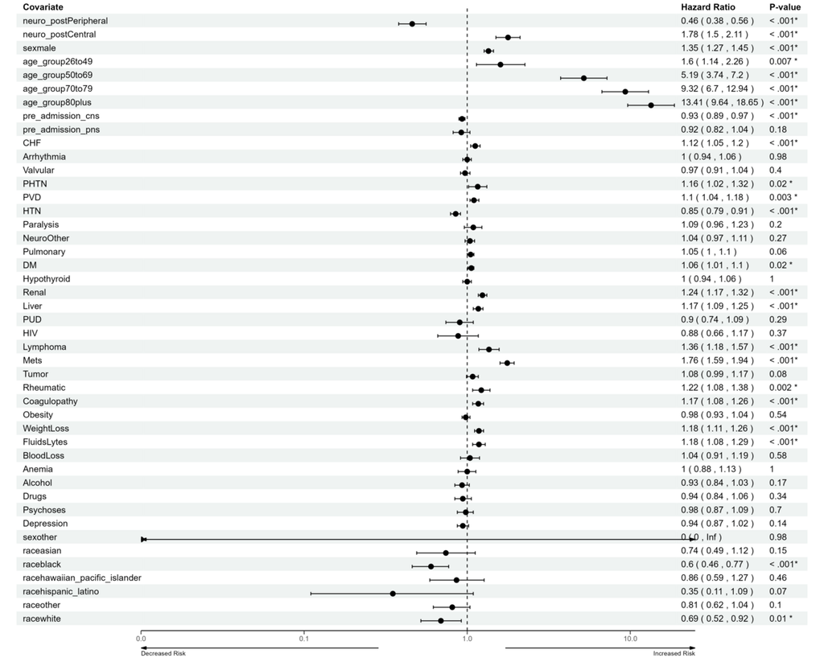

```r
## define forest plot shapes
# shape #16 is normal circle; #18 is diamond
shapes <- rep(16, times = nrow(meta_ind_deceased))
#shapes[length(shapes)] <- 18
sizes <- rep(3.25, times = nrow(meta_ind_deceased))
#sizes[length(sizes)] <- 5
scale <- scale_plot(meta_ind_deceased)

forester(
  left_side_data = meta_ind_deceased %>% select(Covariate),
  estimate = meta_ind_deceased$Estimate,
  ci_low = meta_ind_deceased$lower.random,
  ci_high = meta_ind_deceased$upper.random,
  right_side_data = meta_ind_deceased[, c("Hazard Ratio", "P-value")],
  display = TRUE,
  font_family = "arial",
  arrows = TRUE,
  arrow_labels = c("Decreased Risk", "Increased Risk"),
  null_line_at = 1,
  xlim = c(scale$min_est,25),
  point_sizes = sizes,
  point_shapes = shapes,
  x_scale_linear = FALSE,
  add_plot_width = 5,
  ggplot_width = 100,
  set_png_height = 12.5,
  file_path = here::here(paste0("figures/meta-analysis-coefficients-ind-90-mortality.png")))
```

### **Discharge Results**

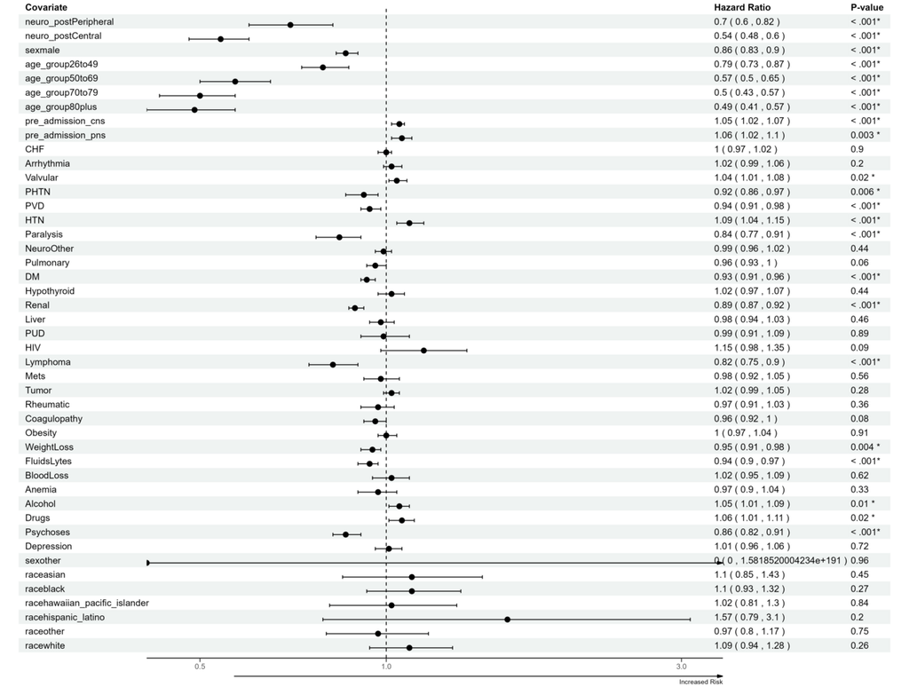

```r
## define forest plot shapes
# shape #16 is normal circle; #18 is diamond
shapes <- rep(16, times = nrow(meta_ind_discharge))
#shapes[length(shapes)] <- 18
sizes <- rep(3.25, times = nrow(meta_ind_discharge))
#sizes[length(sizes)] <- 5
scale <- scale_plot(meta_ind_discharge)

forester(
  left_side_data = meta_ind_discharge %>% select(Covariate),
  estimate = meta_ind_discharge$Estimate,
  ci_low = meta_ind_discharge$lower.random,
  ci_high = meta_ind_discharge$upper.random,
  right_side_data = meta_ind_discharge[, c("Hazard Ratio", "P-value")],
  display = TRUE,
  font_family = "arial",
  arrows = TRUE,
  arrow_labels = c("Decreased Risk", "Increased Risk"),
  null_line_at = 1,
  xlim = c(scale$min_est, 3.5),
  point_sizes = sizes,
  point_shapes = shapes,
  x_scale_linear = FALSE,
  add_plot_width = 5,
  ggplot_width = 100,
  set_png_height = 12.5,
  file_path = here::here(paste0("figures/meta-analysis-coefficients-ind-90-discharge.png")))
```